# RecommendationSys_Project_ShriyaNatesan

```python
# Importing libraries
import pandas as pd
import numpy as np
import seaborn as sns
import matplotlib.pyplot as plt
%matplotlib inline
```

```python
# Importing Data file 1
ph1 = pd.read_csv('DataSets/DataSet/phone_user_review_file_1.csv',encoding = "ISO-8859-1")
ph1.head()
```

|  | phone_url | date | lang | country | source | domain | score | score_max | extract | author | product |
| --- | --- | --- | --- | --- | --- | --- | --- | --- | --- | --- | --- |
| 0 | /cellphones/samsung-galaxy-s8/ | 5/2/2017 | en | us | Verizon Wireless | verizonwireless.com | 10.0 | 10.0 | As a diehard Samsung fan who has had every Sam... | CarolAnn35 | Samsung Galaxy S8 |
| 1 | /cellphones/samsung-galaxy-s8/ | 4/28/2017 | en | us | Phone Arena | phonearena.com | 10.0 | 10.0 | Love the phone. the phone is sleek and smooth ... | james0923 | Samsung Galaxy S8 |
| 2 | /cellphones/samsung-galaxy-s8/ | 5/4/2017 | en | us | Amazon | amazon.com | 6.0 | 10.0 | Adequate feel. Nice heft. Processor's still sl... | R. Craig | Samsung Galaxy S8 (64GB) G950U 5.8" 4G LTE Unl... |
| 3 | /cellphones/samsung-galaxy-s8/ | 5/2/2017 | en | us | Samsung | samsung.com | 9.2 | 10.0 | Never disappointed. One of the reasons I've be... | Buster2020 | Samsung Galaxy S8 64GB (AT&T) |
| 4 | /cellphones/samsung-galaxy-s8/ | 5/11/2017 | en | us | Verizon Wireless | verizonwireless.com | 4.0 | 10.0 | I've now found that i'm in a group of people t... | S Ate Mine | Samsung Galaxy S8 |

```python
print("Dimension of Data Set 1: {}".format(ph1.shape))
```

```
Dimension of Data Set 1: (374910, 11)
```

```python
# Importing Data file 2
ph2 = pd.read_csv('DataSets/DataSet/phone_user_review_file_2.csv',encoding = "ISO-8859-1")
ph2.head()
```

|  | phone_url | date | lang | country | source | domain | score | score_max | extract | author | product |
| --- | --- | --- | --- | --- | --- | --- | --- | --- | --- | --- | --- |
| 0 | /cellphones/leagoo-lead-7/ | 4/15/2015 | en | us | Amazon | amazon.com | 2.0 | 10.0 | The telephone headset is of poor quality , not... | luis | Leagoo Lead7 5.0 Inch HD JDI LTPS Screen 3G Sm... |
| 1 | /cellphones/leagoo-lead-7/ | 5/23/2015 | en | gb | Amazon | amazon.co.uk | 10.0 | 10.0 | This is my first smartphone so I have nothing ... | Mark Lavin | Leagoo Lead 7 Lead7 MTK6582 Quad core 1GB RAM ... |
| 2 | /cellphones/leagoo-lead-7/ | 4/27/2015 | en | gb | Amazon | amazon.co.uk | 8.0 | 10.0 | Great phone. Battery life not great but seems ... | tracey | Leagoo Lead 7 Lead7 MTK6582 Quad core 1GB RAM ... |
| 3 | /cellphones/leagoo-lead-7/ | 4/22/2015 | en | gb | Amazon | amazon.co.uk | 10.0 | 10.0 | Best 90 quid I've ever spent on a smart phone | Reuben Ingram | Leagoo Lead 7 Lead7 MTK6582 Quad core 1GB RAM ... |
| 4 | /cellphones/leagoo-lead-7/ | 4/18/2015 | en | gb | Amazon | amazon.co.uk | 10.0 | 10.0 | I m happy with this phone.it s very good.thx team | viorel | Leagoo Lead 7 Lead7 MTK6582 Quad core 1GB RAM ... |

```python
print("Dimension of Data Set 2: {}".format(ph2.shape))
```

```
Dimension of Data Set 2: (114925, 11)
```

```python
# Importing Data file 3
ph3 = pd.read_csv('DataSets/DataSet/phone_user_review_file_3.csv',encoding = "ISO-8859-1")
ph3.head()
```

|  | phone_url | date | lang | country | source | domain | score | score_max | extract | author | product |
| --- | --- | --- | --- | --- | --- | --- | --- | --- | --- | --- | --- |
| 0 | /cellphones/samsung-galaxy-s-iii-slim-sm-g3812/ | 11/7/2015 | pt | br | Submarino | submarino.com.br | 6.0 | 10.0 | recomendo, eu comprei um, a um ano, e agora co... | herlington tesch | Samsung Smartphone Samsung Galaxy S3 Slim G381... |
| 1 | /cellphones/samsung-galaxy-s-iii-slim-sm-g3812/ | 10/2/2015 | pt | br | Submarino | submarino.com.br | 10.0 | 10.0 | Comprei um pouco desconfiada do site e do celu... | Luisa Silva Marieta | Samsung Smartphone Samsung Galaxy S3 Slim G381... |
| 2 | /cellphones/samsung-galaxy-s-iii-slim-sm-g3812/ | 9/2/2015 | pt | br | Submarino | submarino.com.br | 10.0 | 10.0 | Muito bom o produto, obvio que tem versões me... | Cyrus | Samsung Smartphone Samsung Galaxy S3 Slim G381... |
| 3 | /cellphones/samsung-galaxy-s-iii-slim-sm-g3812/ | 9/2/2015 | pt | br | Submarino | submarino.com.br | 8.0 | 10.0 | Unica ressalva fica para a camera que poderia ... | Marcela Santa Clara Brito | Samsung Smartphone Samsung Galaxy S3 Slim G381... |
| 4 | /cellphones/samsung-galaxy-s-iii-slim-sm-g3812/ | 9/1/2015 | pt | br | Colombo | colombo.com.br | 8.0 | 10.0 | Rapidez e atenção na entrega. O aparelho é ... | Claudine Maria Kuhn Walendorff | Smartphone Samsung Galaxy S3 Slim, Dual Chip, ... |

```python
print("Dimension of Data Set 3: {}".format(ph3.shape))
```

```
Dimension of Data Set 3: (312961, 11)
```

```python
# Importing Data file 4
ph4 = pd.read_csv('DataSets/DataSet/phone_user_review_file_4.csv',encoding = "ISO-8859-1")
ph4.head()
```

|  | phone_url | date | lang | country | source | domain | score | score_max | extract | author | product |
| --- | --- | --- | --- | --- | --- | --- | --- | --- | --- | --- | --- |
| 0 | /cellphones/samsung-s7262-duos-galaxy-ace/ | 3/11/2015 | en | us | Amazon | amazon.com | 2.0 | 10.0 | was not conpatable with my phone as stated. I ... | Frances DeSimone | Samsung Galaxy Star Pro DUOS S7262 Unlocked Ce... |
| 1 | /cellphones/samsung-s7262-duos-galaxy-ace/ | 17/11/2015 | en | in | Zopper | zopper.com | 10.0 | 10.0 | Decent Functions and Easy to Operate Pros:- Th... | Expert Review | Samsung Galaxy Star Pro S7262 Black |
| 2 | /cellphones/samsung-s7262-duos-galaxy-ace/ | 29/10/2015 | en | in | Amazon | amazon.in | 4.0 | 10.0 | Not Good Phone such price. Hang too much and v... | Amazon Customer | Samsung Galaxy Star Pro GT-S7262 (Midnight Black) |
| 3 | /cellphones/samsung-s7262-duos-galaxy-ace/ | 29/10/2015 | en | in | Amazon | amazon.in | 6.0 | 10.0 | not bad for features | Amazon Customer | Samsung Galaxy Star Pro GT-S7262 (Midnight Black) |
| 4 | /cellphones/samsung-s7262-duos-galaxy-ace/ | 29/10/2015 | en | in | Amazon | amazon.in | 10.0 | 10.0 | Excellent product | NHK | Samsung Galaxy Star Pro GT-S7262 (Midnight Black) |

```python
print("Dimension of Data Set 4: {}".format(ph4.shape))
```

```
Dimension of Data Set 4: (98284, 11)
```

```python
# Importing Data file 5
ph5 = pd.read_csv('DataSets/DataSet/phone_user_review_file_5.csv',encoding = "ISO-8859-1")
ph5.head()
```

|  | phone_url | date | lang | country | source | domain | score | score_max | extract | author | product |
| --- | --- | --- | --- | --- | --- | --- | --- | --- | --- | --- | --- |
| 0 | /cellphones/karbonn-k1616/ | 7/13/2016 | en | in | 91 Mobiles | 91mobiles.com | 2.0 | 10.0 | I bought 1 month before. currently speaker is ... | venkatesh | Karbonn K1616 |
| 1 | /cellphones/karbonn-k1616/ | 7/13/2016 | en | in | 91 Mobiles | 91mobiles.com | 6.0 | 10.0 | I just bought one week back, I have Airtel con... | Venkat | Karbonn K1616 |
| 2 | /cellphones/karbonn-k1616/ | 7/13/2016 | en | in | 91 Mobiles | 91mobiles.com | 4.0 | 10.0 | one problem in this handset opera is not worki... | krrish | Karbonn K1616 |
| 3 | /cellphones/karbonn-k1616/ | 4/25/2014 | en | in | Naaptol | naaptol.com | 10.0 | 10.0 | here Karbonn comes up with an another excellen... | BRIJESH CHAUHAN | Karbonn K1616 - Black |
| 4 | /cellphones/karbonn-k1616/ | 4/23/2013 | en | in | Naaptol | naaptol.com | 10.0 | 10.0 | What a phone, all so on Naaptol my god 23% off... | Suraj CHAUHAN | Karbonn K1616 - Black |

```python
print("Dimension of Data Set 5: {}".format(ph5.shape))
```

```
Dimension of Data Set 5: (350216, 11)
```

```python
# Importing Data file 6
ph6 = pd.read_csv('DataSets/DataSet/phone_user_review_file_6.csv',encoding = "ISO-8859-1")
ph6.head()
```

|  | phone_url | date | lang | country | source | domain | score | score_max | extract | author | product |
| --- | --- | --- | --- | --- | --- | --- | --- | --- | --- | --- | --- |
| 0 | /cellphones/samsung-instinct-sph-m800/ | 9/16/2011 | en | us | Phone Arena | phonearena.com | 8.0 | 10.0 | I've had the phone for awhile and it's a prett... | ajabrams95 | Samsung Instinct HD |
| 1 | /cellphones/samsung-instinct-sph-m800/ | 2/13/2014 | en | us | Amazon | amazon.com | 6.0 | 10.0 | to be clear it is not the sellers fault that t... | Stephanie | Samsung SPH M800 Instinct |
| 2 | /cellphones/samsung-instinct-sph-m800/ | 12/30/2011 | en | us | Phone Scoop | phonescoop.com | 9.0 | 10.0 | Well i love this phone. i have had ton of phon... | snickers | Instinct M800 |
| 3 | /cellphones/samsung-instinct-sph-m800/ | 10/18/2008 | en | us | HandCellPhone | handcellphone.com | 4.0 | 10.0 | I have had my Instinct for several months now ... | A4C | Samsung Instinct |
| 4 | /cellphones/samsung-instinct-sph-m800/ | 9/6/2008 | en | us | Reviewed.com | reviewed.com | 6.0 | 10.0 | i have had this instinct phone for about two m... | betaBgood | Samsung Instinct |

```python
print("Dimension of Data Set 6: {}".format(ph6.shape))
```

```
Dimension of Data Set 6: (163837, 11)
```

```python
print('Check whether the column names are same in all the dataframes: ')
all(np.unique(ph6.columns.tolist()) == np.unique(ph1.columns.tolist()+
                                                      ph2.columns.tolist()+
                                                      ph3.columns.tolist()+
                                                      ph4.columns.tolist()+
                                                      ph5.columns.tolist()+
                                                      ph6.columns.tolist()))
```

```
Check whether the column names are same in all the dataframes:
```

```
True
```

### 1.a) Merge all the datasets

```python
ph_new = pd.concat([ph1, ph2, ph3, ph4, ph5, ph6])
ph_new
```

|  | phone_url | date | lang | country | source | domain | score | score_max | extract | author | product |
| --- | --- | --- | --- | --- | --- | --- | --- | --- | --- | --- | --- |
| 0 | /cellphones/samsung-galaxy-s8/ | 5/2/2017 | en | us | Verizon Wireless | verizonwireless.com | 10.0 | 10.0 | As a diehard Samsung fan who has had every Sam... | CarolAnn35 | Samsung Galaxy S8 |
| 1 | /cellphones/samsung-galaxy-s8/ | 4/28/2017 | en | us | Phone Arena | phonearena.com | 10.0 | 10.0 | Love the phone. the phone is sleek and smooth ... | james0923 | Samsung Galaxy S8 |
| 2 | /cellphones/samsung-galaxy-s8/ | 5/4/2017 | en | us | Amazon | amazon.com | 6.0 | 10.0 | Adequate feel. Nice heft. Processor's still sl... | R. Craig | Samsung Galaxy S8 (64GB) G950U 5.8" 4G LTE Unl... |
| 3 | /cellphones/samsung-galaxy-s8/ | 5/2/2017 | en | us | Samsung | samsung.com | 9.2 | 10.0 | Never disappointed. One of the reasons I've be... | Buster2020 | Samsung Galaxy S8 64GB (AT&T) |
| 4 | /cellphones/samsung-galaxy-s8/ | 5/11/2017 | en | us | Verizon Wireless | verizonwireless.com | 4.0 | 10.0 | I've now found that i'm in a group of people t... | S Ate Mine | Samsung Galaxy S8 |
| ... | ... | ... | ... | ... | ... | ... | ... | ... | ... | ... | ... |
| 163832 | /cellphones/alcatel-ot-club_1187/ | 5/12/2000 | de | de | Ciao | ciao.de | 2.0 | 10.0 | Weil mein Onkel bei ALcatel arbeitet habe ich ... | david.paul | Alcatel Club Plus Handy |
| 163833 | /cellphones/alcatel-ot-club_1187/ | 5/11/2000 | de | de | Ciao | ciao.de | 10.0 | 10.0 | Hy Liebe Leserinnen und Leser!! Ich habe seit ... | Christiane14 | Alcatel Club Plus Handy |
| 163834 | /cellphones/alcatel-ot-club_1187/ | 5/4/2000 | de | de | Ciao | ciao.de | 2.0 | 10.0 | Jetzt hat wohl Alcatell gedacht ,sie machen wa... | michaelawr | Alcatel Club Plus Handy |
| 163835 | /cellphones/alcatel-ot-club_1187/ | 5/1/2000 | de | de | Ciao | ciao.de | 8.0 | 10.0 | Ich bin seit 2 Jahren (stolzer) Besitzer eines... | claudia0815 | Alcatel Club Plus Handy |
| 163836 | /cellphones/alcatel-ot-club_1187/ | 4/25/2000 | de | de | Ciao | ciao.de | 2.0 | 10.0 | Was sich Alkatel hier wieder ausgedacht hat,sc... | michaelawr | Alcatel Club Plus Handy |

1415133 rows × 11 columns

### 1.b) Check a few observations and shape of the data-frame.

```python
print("Dimension of the merged Data Set: {}".format(ph_new.shape))
```

```
Dimension of the merged Data Set: (1415133, 11)
```

```python
ph_new.info()
```

```
<class 'pandas.core.frame.DataFrame'>
Int64Index: 1415133 entries, 0 to 163836
Data columns (total 11 columns):
 #   Column     Non-Null Count    Dtype
---  ------     --------------    -----
 0   phone_url  1415133 non-null  object
 1   date       1415133 non-null  object
 2   lang       1415133 non-null  object
 3   country    1415133 non-null  object
 4   source     1415133 non-null  object
 5   domain     1415133 non-null  object
 6   score      1351644 non-null  float64
 7   score_max  1351644 non-null  float64
 8   extract    1395772 non-null  object
 9   author     1351931 non-null  object
 10  product    1415132 non-null  object
dtypes: float64(2), object(9)
memory usage: 129.6+ MB
```

- Except score and score_max (which are of float type) all other features are of object type
- Column date should be of datetype
- score, score_max, extract and author columns seems to have Null values

```python
print('Number of unique values in each feature: \n',ph_new.nunique())

##score_max for all the phones is 10 throughout
```

```
Number of unique values in each feature:
 phone_url       5556
date            7728
lang              22
country           42
source           331
domain           384
score             86
score_max          1
extract      1321353
author        801103
product        61313
dtype: int64
```

```python
#Top 10 Non-english users
ph_new[ph_new['lang']!='en']['author'].value_counts(ascending=False)[:10]
```

```
Cliente Amazon        19276
e-bit                  8663
Client d'Amazon        7613
Amazon Kunde           4735
Amazon Customer        2713
einer Kundin           2610
einem Kunden           1898
unknown                1718
ÐÐ»ÐµÐºÑÐ°Ð½Ð´Ñ     1070
Ð¡ÐµÑÐ³ÐµÐ¹            904
Name: author, dtype: int64
```

```python
#Top 10 Non-english products
ph_new[ph_new['lang']!='en']['product'].value_counts(ascending=False)[:10]
```

```
Huawei P8lite zwart / 16 GB                                                                                                                                                                  2707
Samsung Galaxy Express I8730                                                                                                                                                                 2686
Samsung Galaxy S6 zwart / 32 GB                                                                                                                                                              2345
Nokia 5800 XpressMusic                                                                                                                                                                       1996
Nokia N95                                                                                                                                                                                    1848
Huawei P9 Lite Smartphone, LTE, Display 5.2'' FHD, Processore Octa-Core Kirin 650, 16 GB Memoria Interna, 3GB RAM, Fotocamera 13 MP, Single-SIM, Android 6.0 Marshmallow, Bianco [Italia]    1720
Samsung Galaxy S6 edge zwart / 32 GB                                                                                                                                                         1708
Nokia N8                                                                                                                                                                                     1699
Nokia 5800                                                                                                                                                                                   1588
Huawei P8 Lite Smartphone, Display 5" IPS, Processore Octa-Core 1.5 GHz, Memoria Interna da 16 GB, 2 GB RAM, Fotocamera 13 MP, monoSIM, Android 5.0, Bianco [Italia]                         1577
Name: product, dtype: int64
```

```python
# print the frequency count of phone_url column
ph_new['phone_url'].value_counts(ascending=False).head(50)
```

```
/cellphones/samsung-galaxy-s-iii/                                 17093
/cellphones/apple-iphone-5s/                                      16379
/cellphones/samsung-galaxy-s6/                                    16145
/cellphones/samsung-galaxy-s5/                                    16082
/cellphones/samsung-galaxy-s7-edge/                               15917
/cellphones/motorola-moto-g/                                      14476
/cellphones/samsung-galaxy-s7-789999/                             13488
/cellphones/samsung-i9500-galaxy-s-iv/                            13161
/cellphones/huawei-p8-lite/                                       12629
/cellphones/lenovo-vibe-k4-note/                                   9662
/cellphones/samsung-galaxy-s4-mini-gt-i9190-gt-i9192-dual-sim/     9027
/cellphones/samsung-galaxy-s6-edge-sm-g925f/                       8844
/cellphones/apple-iphone-4s/                                       8602
/cellphones/samsung-galaxy-s3-mini/                                8388
/cellphones/lg-g3-d855-657484/                                     7992
/cellphones/oneplus-3/                                             7944
/cellphones/lenovo-vibe-k5/                                        7892
/cellphones/apple-iphone-5/                                        7821
/cellphones/apple-iphone-6/                                        7820
/cellphones/apple-iphone-4/                                        7289
/cellphones/lg-g4/                                                 7060
/cellphones/lg-g2-594708/                                          6621
/cellphones/apple-iphone-5c/                                       6157
/cellphones/apple-iphone-6s/                                       6137
/cellphones/samsung-galaxy-ace-s5830/                              6064
/cellphones/motorola-moto-e/                                       6031
/cellphones/samsung-galaxy-j3-duos/                                5936
/cellphones/apple-iphone-7/                                        5839
/cellphones/samsung-s5230/                                         5824
/cellphones/samsung-galaxy-note-iii/                               5806
/cellphones/huawei-p9-lite/                                        5553
/cellphones/samsung-galaxy-s-ii/                                   5425
/cellphones/nokia-5800-xpressmusic-tube/                           5179
/cellphones/samsung-galaxy-note-2/                                 5001
/cellphones/samsung-galaxy-j5/                                     4933
/cellphones/samsung-galaxy-note-4/                                 4885
/cellphones/nokia-lumia-520/                                       4883
/cellphones/samsung-galaxy-s6-edgeplus/                            4776
/cellphones/motorola-moto-g3/                                      4619
/cellphones/lg-google-nexus-5/                                     4549
/cellphones/microsoft-lumia-640-dual-sim/                          4523
/cellphones/apple-iphone-se/                                       4425
/cellphones/motorola-moto-g4/                                      4420
/cellphones/htc-one-m7/                                            4349
/cellphones/nokia-lumia-630/                                       4187
/cellphones/google-nexus-5x-h791/                                  4169
/cellphones/samsung-galaxy-a3-2016/                                4025
/cellphones/asus-zenfone-2/                                        3980
/cellphones/nokia-n95/                                             3912
/cellphones/sony-xperia-z3-compact/                                3870
Name: phone_url, dtype: int64
```

### 1.c) Round off scores to the nearest integers.

```python
ph_new2 = ph_new
ph_new2['score'] = ph_new2['score'].fillna(0)
round(ph_new2['score']).astype(int)
```

```
0         10
1         10
2          6
3          9
4          4
          ..
163832     2
163833    10
163834     2
163835     8
163836     2
Name: score, Length: 1415133, dtype: int32
```

### 1.d) Check for missing values. Impute the missing values if there is any

```python
ph_new2.isnull().sum()
```

```
phone_url        0
date             0
lang             0
country          0
source           0
domain           0
score            0
score_max    63489
extract      19361
author       63202
product          1
dtype: int64
```

```python
ph_new2.describe().transpose()
```

|  | count | mean | std | min | 25% | 50% | 75% | max |
| --- | --- | --- | --- | --- | --- | --- | --- | --- |
| score | 1415133.0 | 7.647828 | 3.047027 | 0.0 | 6.0 | 8.4 | 10.0 | 10.0 |
| score_max | 1351644.0 | 10.000000 | 0.000000 | 10.0 | 10.0 | 10.0 | 10.0 | 10.0 |

```python
## Filling score max columns with the median values
ph_new2 = ph_new2.fillna(ph_new2.median())
ph_new2.isnull().sum()
```

```
phone_url        0
date             0
lang             0
country          0
source           0
domain           0
score            0
score_max        0
extract      19361
author       63202
product          1
dtype: int64
```

```python
# dropping the null values in columns 'extract' ,'author' and 'product'
ph_new2 = ph_new2.dropna()
```

```python
ph_new2.isnull().sum()
```

```
phone_url    0
date         0
lang         0
country      0
source       0
domain       0
score        0
score_max    0
extract      0
author       0
product      0
dtype: int64
```

```python
ph_new2.shape
```

```
(1336416, 11)
```

### 1.e) Check for duplicate values and remove them if there is any

```python
ph_new2 = ph_new2.drop_duplicates()
```

```python
ph_new2.shape
```

```
(1331607, 11)
```

### 1.g) Drop irrelevant features. Keep features like Author, Product, and Score.

```python
ph_new3 = ph_new2
ph_new3.drop(['phone_url','date','lang','country','source','domain','score_max','extract'], axis = 1, inplace = True)
ph_new3.head()
```

|  | score | author | product |
| --- | --- | --- | --- |
| 0 | 10.0 | CarolAnn35 | Samsung Galaxy S8 |
| 1 | 10.0 | james0923 | Samsung Galaxy S8 |
| 2 | 6.0 | R. Craig | Samsung Galaxy S8 (64GB) G950U 5.8" 4G LTE Unl... |
| 3 | 9.2 | Buster2020 | Samsung Galaxy S8 64GB (AT&T) |
| 4 | 4.0 | S Ate Mine | Samsung Galaxy S8 |

```
Distribution of number of ratings per item (Clipped at 10):
 Lenovo Vibe K4 Note (White,16GB)                5223
Lenovo Vibe K4 Note (Black, 16GB)               4389
OnePlus 3 (Graphite, 64 GB)                     4103
OnePlus 3 (Soft Gold, 64 GB)                    3557
Huawei P8lite zwart / 16 GB                     2707
Samsung Galaxy Express I8730                    2672
Lenovo Vibe K5 (Gold, VoLTE update)             2534
Samsung Galaxy S6 zwart / 32 GB                 2342
Lenovo Vibe K5 (Grey, VoLTE update)             2108
Lenovo Used Lenovo Zuk Z1 (Space Grey, 64GB)    1951
Name: product, dtype: int64
```

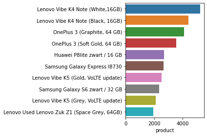

```python
product = ph_new3['product'].value_counts()[:10]
print('Distribution of number of ratings per item (Clipped at 10): \n',product)
sns.barplot(y=product.index,x=product)
plt.tight_layout()
plt.show()
```

```
Distribution of number of ratings per user(Clipped at 10):
 Amazon Customer    76933
Cliente Amazon     19300
e-bit               8411
Client d'Amazon     7716
Amazon Kunde        4746
Anonymous           2611
einer Kundin        2610
einem Kunden        1898
unknown             1725
Anonymous           1460
Name: author, dtype: int64
```

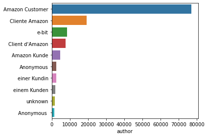

```python
users = ph_new3['author'].value_counts(dropna=False)[:10]
print('Distribution of number of ratings per user(Clipped at 10): \n',users)
users.index = users.index.map(str)
sns.barplot(y=users.index,x=users)
plt.tight_layout()
plt.show()
```

### 1.f) Keep only 1000000 data samples. Use random state=612.

```python
df = ph_new3.sample(n=1000000, random_state=612)
```

```python
df.shape
```

```
(1000000, 3)
```

### 2.a) Identify the most rated features.

```python
#sorting the products which have got highest mean score
df.groupby('product')['score'].mean().sort_values(ascending=False).head()
```

```
product
Samsung J100 Galaxy J1 Smartphone, 4 GB, Marchio TIM, Bianco [Italia]    10.0
Huawei P10 âAndroid-puhelin Dual-SIM, kulta                            10.0
Huawei Nova Dual-SIM grey unlocked                                       10.0
Huawei Nova Plus 32GB Dual-Sim ohne Vertrag grey                         10.0
Samsung Omnia II i8000 (8GB) Zwart                                       10.0
Name: score, dtype: float64
```

```python
# The product that got most number of reviews.
df['product'].value_counts().head()
```

```
Lenovo Vibe K4 Note (White,16GB)     3908
Lenovo Vibe K4 Note (Black, 16GB)    3234
OnePlus 3 (Graphite, 64 GB)          3128
OnePlus 3 (Soft Gold, 64 GB)         2643
Samsung Galaxy Express I8730         2012
Name: product, dtype: int64
```

### 2.b) Identify the users with most number of reviews.

```python
(df['author'].value_counts()).head()
```

```
Amazon Customer    57792
Cliente Amazon     14624
e-bit               6317
Client d'Amazon     5698
Amazon Kunde        3574
Name: author, dtype: int64
```

### 2.c) Select the data with products having more than 50 ratings and users who have given more than 50 ratings. Report the shape of the final dataset

- Get the authors who have gave more than 50 ratings
- Get the products who got more than 50 ratings
- Get the rows from main dataset where product has more than 50 ratings
- Find those rows from the extracted rows corresponding to the authors who gave more than 50 ratings

```python
# extracting authors who gave greater than 50 ratings
df1 = pd.DataFrame(columns=['author', 'a_count'])
df1['author']=df['author'].value_counts().index.tolist()
df1['a_count'] = list(df['author'].value_counts() > 50)
df1
```

|  | author | a_count |
| --- | --- | --- |
| 0 | Amazon Customer | True |
| 1 | Cliente Amazon | True |
| 2 | e-bit | True |
| 3 | Client d'Amazon | True |
| 4 | Amazon Kunde | True |
| ... | ... | ... |
| 620163 | actormodel | False |
| 620164 | BenP | False |
| 620165 | pro74 | False |
| 620166 | JOLY | False |
| 620167 | JasonNMemphis | False |

620168 rows × 2 columns

```python
# get names of indexes for which count column value is False
index_names = df1[ df1['a_count'] == False ].index
# drop these row indexes from dataFrame
df1.drop(index_names, inplace = True)
df1
```

|  | author | a_count |
| --- | --- | --- |
| 0 | Amazon Customer | True |
| 1 | Cliente Amazon | True |
| 2 | e-bit | True |
| 3 | Client d'Amazon | True |
| 4 | Amazon Kunde | True |
| ... | ... | ... |
| 669 | robert | True |
| 670 | Carla | True |
| 671 | Pasquale | True |
| 672 | Bezlikiy_Djo | True |
| 673 | Hugo | True |

674 rows × 2 columns

```python
# extracting product that got more than 50 ratings
df2 = pd.DataFrame(columns=['product', 'p_count'])
df2['product']=df['product'].value_counts().index.tolist()
df2['p_count'] = list(df['product'].value_counts() > 50)
df2
```

|  | product | p_count |
| --- | --- | --- |
| 0 | Lenovo Vibe K4 Note (White,16GB) | True |
| 1 | Lenovo Vibe K4 Note (Black, 16GB) | True |
| 2 | OnePlus 3 (Graphite, 64 GB) | True |
| 3 | OnePlus 3 (Soft Gold, 64 GB) | True |
| 4 | Samsung Galaxy Express I8730 | True |
| ... | ... | ... |
| 55981 | Motorola Moto Z Play grijs, zwart / 32 GB | False |
| 55982 | Smartphone Samsung Galaxy Ace 4 Lite Duos Dual... | False |
| 55983 | NOKIA 2310 CEP TELEFONU | False |
| 55984 | SAMSUNG Marvel Black Unlocked GSM Touch Screen... | False |
| 55985 | Nokia X1-01 Dual Sim Phone | False |

55986 rows × 2 columns

```python
# get names of indexes for which count column value is False
index_names = df2[ df2['p_count'] == False ].index
# drop these row indexes from dataFrame
df2.drop(index_names, inplace = True)
df2
```

|  | product | p_count |
| --- | --- | --- |
| 0 | Lenovo Vibe K4 Note (White,16GB) | True |
| 1 | Lenovo Vibe K4 Note (Black, 16GB) | True |
| 2 | OnePlus 3 (Graphite, 64 GB) | True |
| 3 | OnePlus 3 (Soft Gold, 64 GB) | True |
| 4 | Samsung Galaxy Express I8730 | True |
| ... | ... | ... |
| 4375 | Asus ZenFone 4.5 Smartphone, Storage 8 GB, Ner... | True |
| 4376 | Lava Iris X5 (Black) | True |
| 4377 | Sony CMD-C1 | True |
| 4378 | Samsung S5230 Hello Kitty Pink Unlocked GSM Qu... | True |
| 4379 | Nokia 5140i | True |

4380 rows × 2 columns

```python
# selecting data rows where product is having more than 50 ratings.
df3 = df[df['product'].isin(df2['product'])]
df3
```

|  | score | author | product |
| --- | --- | --- | --- |
| 4635 | 10.0 | Dieter Kraft | Microsoft Nokia Lumia 630 Single-SIM Smartphon... |
| 300224 | 10.0 | derrrickman | Kyocera Kona Black (Virgin Mobile) |
| 352217 | 8.0 | mario | Samsung G900 Galaxy S5 Smartphone, 16 GB, Nero... |
| 66629 | 8.0 | Darpan | OnePlus One (Sandstone Black, 64GB) |
| 77416 | 10.0 | Amazon Customer | OnePlus 3 (Graphite, 64 GB) |
| ... | ... | ... | ... |
| 167436 | 6.0 | vikaaay | Nokia C3-00 |
| 179434 | 8.6 | missylee | Huawei P8 Lite wit / 16 GB |
| 87170 | 6.0 | Sergio | Huawei Ascend Y330 - Smartphone libre Android ... |
| 281617 | 10.0 | matteo anatrella | Huawei Ascend G510 Smartphone Touch, Fotocamer... |
| 110878 | 2.0 | Ernest | Apple iPhone 5C 8GB Factory Unlocked GSM Cell ... |

559763 rows × 3 columns

```python
# selecting data rows from df3 where author has given more than 50 ratings.
# so that we get the data with products having more than 50 ratings and users who have given more than 50 ratings
df4 = df3[df3['author'].isin(df1['author'])]
df4
```

|  | score | author | product |
| --- | --- | --- | --- |
| 352217 | 8.0 | mario | Samsung G900 Galaxy S5 Smartphone, 16 GB, Nero... |
| 77416 | 10.0 | Amazon Customer | OnePlus 3 (Graphite, 64 GB) |
| 41513 | 10.0 | Amazon Customer | Apple iPhone 5s (Space Grey, 16GB) |
| 22820 | 8.0 | Amazon Customer | Lenovo Vibe K5 (Grey, VoLTE update) |
| 34166 | 10.0 | Roberto | LG G3 8806084954985 4G 16GB Black smartphone -... |
| ... | ... | ... | ... |
| 177801 | 10.0 | Cliente Amazon | Huawei P8 lite Smartphone, Display 5.0" IPS, D... |
| 21110 | 2.0 | Amazon customer | Tracfone Motorola Moto E Android Prepaid Phone... |
| 114020 | 10.0 | Nicola | Apple iPhone 5C 16GB - sbloccato - blu / ciano |
| 160660 | 8.0 | Cliente Amazon | Blackview BV5000 Lte 4G- Smartphone Libre Andr... |
| 87170 | 6.0 | Sergio | Huawei Ascend Y330 - Smartphone libre Android ... |

108809 rows × 3 columns

```python
#Report the shape of the final dataset.
df4.shape
```

```
(108809, 3)
```

### 3) Build a popularity based model and recommend top 5 mobile phones

```python
#calculating the mean score for a product by grouping it.
ratings_mean_count = pd.DataFrame(df4.groupby('product')['score'].mean())
```

```python
#calculating the number of ratings a product got
ratings_mean_count['rating_counts'] = pd.DataFrame(df4.groupby('product')['score'].count())
```

```python
#Recommending the 5 mobile phones based in highest mean score and highest number of ratings the product got.
ratings_mean_count.sort_values(by=['score','rating_counts'], ascending=[False,False]).head()
```

| product | score | rating_counts |
| --- | --- | --- |
| Samsung Galaxy Note5 | 10.0 | 56 |
| Samsung Galaxy S7 Edge 32Gb | 10.0 | 13 |
| Sim Free Apple iPhone SE 64GB Mobile Phone - Space Grey | 10.0 | 12 |
| HTC One (32Gb) | 10.0 | 11 |
| Samsung Galaxy S III, Purple 16GB (Sprint) | 10.0 | 9 |

#### If we consider the 1000000 sampled data, we see the different results for 2nd, 3rd, 4th, 5th product positions.

```python
#calculating the mean score for a product by grouping it.
ratings_mean_count = pd.DataFrame(df.groupby('product')['score'].mean())

#calculating the number of ratings a product got
ratings_mean_count['rating_counts'] = pd.DataFrame(df.groupby('product')['score'].count())

#Recommending the 5 mobile phones based in highest mean score and highest number of ratings the product got.
ratings_mean_count.sort_values(by=['score','rating_counts'], ascending=[False,False]).head()
```

| product | score | rating_counts |
| --- | --- | --- |
| Samsung Galaxy Note5 | 10.0 | 144 |
| Motorola Smartphone Motorola Moto X Desbloqueado Preto Android 4.2.2 Câmera 10MP e Frontal 2MP Memória Interna de 16GB GSM | 10.0 | 143 |
| Nokia Smartphone Nokia Lumia 520 Desbloqueado Oi Preto Windows Phone 8 Câmera 5MP 3G Wi-Fi Memória Interna 8G GPS | 10.0 | 129 |
| Motorola Smartphone Motorola Moto G Dual Chip Desbloqueado TIM Android 4.3 Tela 4.5 8GB 3G Wi-Fi Câmera 5MP - Preto | 10.0 | 126 |
| Motorola Smartphone Motorola Novo Moto G DTV Colors Dual Chip XT 1069 Desbloqueado Android 4.4 Tela 5 16GB 3G Wi-Fi Câmera de 8MP - Preto | 10.0 | 119 |

### 4.a) Build a collaborative filtering model using SVD. You can use SVD from surprise or build it from scratch(Note: Incase you’re building it from scratch you can limit your data points to 5000 samples if you face memory issues).

```python
from surprise import SVD
from surprise import KNNWithMeans
from surprise import Dataset
from surprise import accuracy
from surprise import Reader
from surprise.model_selection import cross_validate
from surprise.model_selection import train_test_split

# Suppressing Warnings
import warnings
warnings.filterwarnings('ignore')
```

```python
collab1 = df4.copy()
collab1.shape
```

```
(108809, 3)
```

- We will be using the same trainset and testset for SVD, KNN(user based) and (item based)
- We will fit the model, use it for predictions, calculate the RMSE
- After doing for all three we will compare the RMSE values

```python
# Rearrange columns for SVD and prepare train and testsets
collab2 = Dataset.load_from_df(collab1[['author','product','score']], Reader(rating_scale=(1, 10)))
trainset, testset = train_test_split(collab2, test_size=.25,random_state=612)

print('top 3 values from trainset: \n')
for key,value in {k: v for k, v in trainset.ur.items() if k <= 2}.items(): print(key,'-> ',value,'\n')
print('\ntop 3 values from testset: ', *testset[0:3], sep='\n\n')
```

```
top 3 values from trainset:

0 ->  [(0, 8.0), (41, 6.0), (78, 10.0), (79, 8.0), (86, 4.0), (79, 10.0), (93, 10.0), (107, 10.0), (79, 10.0), (220, 8.0), (235, 8.0), (78, 10.0), (236, 6.0), (220, 8.0), (86, 10.0), (331, 10.0), (356, 10.0), (380, 10.0), (384, 10.0), (356, 10.0), (79, 10.0), (420, 10.0), (431, 8.0), (455, 10.0), (3…

1 ->  [(1, 2.0), (4, 10.0), (6, 8.0), (7, 2.0), (9, 2.0), (10, 6.0), (12, 6.0), (20, 2.0), (25, 10.0), (26, 6.0), (28, 2.0), (29, 8.0), (32, 10.0), (33, 2.0), (34, 10.0), (4, 8.0), (37, 8.0), (39, 10.0), (40, 2.0), (4, 8.0), (39, 10.0), (48, 10.0), (49, 8.0), (60, 8.0), (63, 2.0), (64, 2.0), (66, 2.…

2 ->  [(2, 8.6), (367, 10.0), (777, 4.0), (661, 10.0), (316, 2.0), (1583, 10.0), (175, 10.0), (2237, 10.0), (310, 9.6), (2569, 9.0), (1537, 10.0), (310, 8.8), (1866, 2.0), (903, 10.0), (2472, 10.0), (669, 9.0), (151, 2.0), (599, 2.0), (1525, 10.0), (3095, 8.0), (3225, 8.0), (1167, 9.8), (3382, 8.0),…


top 3 values from testset:

('michael', 'Microsoft Nokia 515 DE Smartphone ( 6,1 cm (2,4 Zoll) Farbdisplay, 5 Megapixel Digitalkamera, Bluetooth 3.0) schwarz', 10.0)

('Elena', 'Huawei P8 Champagne / 16 GB', 9.0)

('e-bit', 'Smartphone Samsung Galaxy S6 Edge SM-G925 32GB', 10.0)
```

```python
# fit and predict using svd
def svd_func(train, test):
    svd = SVD(random_state=612)
    svd.fit(train)
    svd_pred = svd.test(test)
    return svd_pred, svd

svd_pred, svd = svd_func(trainset,testset)
print('First few prediction values: \n',svd_pred[0:2])
print('\nRMSE value(SVD model): ',round(accuracy.rmse(svd_pred),2),'\n') # compute RMSE
svd_rmse = round(accuracy.rmse(svd_pred),2)
```

```
First few prediction values:
 [Prediction(uid='michael', iid='Microsoft Nokia 515 DE Smartphone ( 6,1 cm (2,4 Zoll) Farbdisplay, 5 Megapixel Digitalkamera, Bluetooth 3.0) schwarz', r_ui=10.0, est=8.555564549356681, details={'was_impossible': False}), Prediction(uid='Elena', iid='Huawei P8 Champagne / 16 GB', r_ui=9.0, est=7.945…
RMSE: 2.7997

RMSE value(SVD model):  2.8

RMSE: 2.7997
```

### 4.b) Build a collaborative filtering model using kNNWithMeans from surprise. (user-based model)

```python
# fit and predict using knn
def knn_user(train, test):
    knn_u = KNNWithMeans(k=50, sim_options={'name': 'pearson_baseline', 'user_based': True})
    knn_u.fit(train)
    knn_u_pred = knn_u.test(test)
    return knn_u_pred, knn_u
```

```python
knn_u_pred, knn_u = knn_user(trainset, testset)
print('First few prediction values: \n',knn_u_pred[0:2])
```

```
Estimating biases using als...
Computing the pearson_baseline similarity matrix...
Done computing similarity matrix.
First few prediction values:
 [Prediction(uid='michael', iid='Microsoft Nokia 515 DE Smartphone ( 6,1 cm (2,4 Zoll) Farbdisplay, 5 Megapixel Digitalkamera, Bluetooth 3.0) schwarz', r_ui=10.0, est=5.256792958285495, details={'actual_k': 1, 'was_impossible': False}), Prediction(uid='Elena', iid='Huawei P8 Champagne / 16 GB', r_ui…
```

```python
print('\nRMSE value(Knn-User-based Model, test-set): ',round(accuracy.rmse(knn_u_pred),2),'\n') # compute RMSE
knn_u_rmse = round(accuracy.rmse(knn_u_pred),2)
```

```
RMSE: 2.8815

RMSE value(Knn-User-based Model, test-set):  2.88

RMSE: 2.8815
```

### 4.c) Build a collaborative filtering model using kNNWithMeans from surprise. (item-based model)

```python
# fit and predict using knn
def knn_item(train, test):
    knn_i = KNNWithMeans(k=50, sim_options={'name': 'pearson_baseline', 'user_based': False})
    knn_i.fit(train)
    knn_i_pred = knn_i.test(test)
    return knn_i_pred, knn_i
```

```python
knn_i_pred, knn_i = knn_item(trainset, testset)
print('First few prediction values: \n',knn_i_pred[0:2])
```

```
Estimating biases using als...
Computing the pearson_baseline similarity matrix...
Done computing similarity matrix.
First few prediction values:
 [Prediction(uid='michael', iid='Microsoft Nokia 515 DE Smartphone ( 6,1 cm (2,4 Zoll) Farbdisplay, 5 Megapixel Digitalkamera, Bluetooth 3.0) schwarz', r_ui=10.0, est=6.076525337346768, details={'actual_k': 4, 'was_impossible': False}), Prediction(uid='Elena', iid='Huawei P8 Champagne / 16 GB', r_ui…
```

```python
print('\nRMSE value(Knn-Item-based Model, test-set): ',round(accuracy.rmse(knn_i_pred),2),'\n') # compute RMSE
knn_i_rmse = round(accuracy.rmse(knn_i_pred),2)
```

```
RMSE: 2.8239

RMSE value(Knn-Item-based Model, test-set):  2.82

RMSE: 2.8239
```

### 5. Evaluate the collaborative model. Print RMSE value

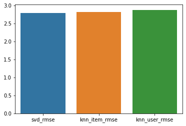

```python
#Comparison of RMSE scores
sns.barplot(x=['svd_rmse','knn_item_rmse', 'knn_user_rmse'],y=[svd_rmse,knn_i_rmse, knn_u_rmse])
```

We can see all three are quite close, best is SVD with RMSE of 2.7997

### 6. Predict score (average rating) for test users.

```python
svd_pred_df=pd.DataFrame(svd_pred, columns=['uid', 'iid', 'rui', 'est', 'details'])
print('average prediction for test users: ',svd_pred_df['est'].mean())
print('average rating  by test users: ',svd_pred_df['rui'].mean())
print('average prediction error for test users: ',(svd_pred_df['rui']-svd_pred_df['est']).abs().mean())
```

```
average prediction for test users:  7.506983276159134
average rating  by test users:  7.459162592361123
average prediction error for test users:  2.1991428945162337
```

```python
knn_u_pred_df=pd.DataFrame(knn_u_pred, columns=['uid', 'iid', 'rui', 'est', 'details'])
print('average prediction for test users: ',knn_u_pred_df['est'].mean())
print('average rating  by test users: ',knn_u_pred_df['rui'].mean())
print('average prediction error for test users: ',(knn_u_pred_df['rui']-knn_u_pred_df['est']).abs().mean())
```

```
average prediction for test users:  7.490268859041193
average rating  by test users:  7.459162592361123
average prediction error for test users:  2.20888287751977
```

```python
knn_i_pred_df=pd.DataFrame(knn_i_pred, columns=['uid', 'iid', 'rui', 'est', 'details'])
print('average prediction for test users: ',knn_i_pred_df['est'].mean())
print('average rating  by test users: ',knn_i_pred_df['rui'].mean())
print('average prediction error for test users: ',(knn_i_pred_df['rui']-knn_i_pred_df['est']).abs().mean())
```

```
average prediction for test users:  7.465585790409615
average rating  by test users:  7.459162592361123
average prediction error for test users:  2.1930712308123046
```

As we can see, The average rating by test users and the average prediction is the closeset for the knn item based model

This explains its least prediction error among all the 3 models.

### 7. Report your findings and inferences.

- Samsung Galaxy Note 5 is a highly recommended phone from the popularity based model.
- Most of the authors have given the rating of '10' or '8'
- All 3 algorithms have a very close RMSE value.
- Overall data is highly skewed towards 'Amazon customers' from different countries.
- Since Amazon is a leading giant in selling smartphones many users are realted to amazon but usernames are not correct.
- Many unknown users and anonymous users exist which seem to take a large chunk of the data.

### 8. Try and recommend top 5 products for test users

```python
from collections import defaultdict
def get_top_n(predictions, n=5):
    # First map the predictions to each user.
    top_n = defaultdict(list)
    for uid, iid, true_r, est, _ in predictions:
        top_n[uid].append((iid, est))

    # Then sort the predictions for each user and retrieve the k highest ones.
    for uid, user_ratings in top_n.items():
        user_ratings.sort(key=lambda x: x[1], reverse=True)
        top_n[uid] = user_ratings[:n]

    return top_n
```

```python
top_5 = get_top_n(svd_pred,5)
print('Top 5 recommendations for all test users (using the SVD MODEL) are: ')
for key,value in top_5.items(): print('User : ',key,'--->',value,'\n')
```

```
Top 5 recommendations for all test users (using the SVD MODEL) are:
User :  michael ---> [('HTC ONE M8 5" 16GB 4G LTE ANDROID 4.4 EUROPA GRAY', 9.326107210257538), ('Alcatel OneTouch Idol 3 Global Unlocked 4G LTE Smartphone, 5.5 HD IPS Display, 16GB (GSM - US Warranty)', 9.32366939768644), ('Microsoft Lumia 640 5 inch SIM-Free Smartphone - Black', 8.972622625568997)…

User :  Elena ---> [('Motorola Moto G 4G SIM-Free Smartphone - Black (8GB) - Discontinued by manufacturer', 9.684734703760123), ('Samsung A520 Smartphone, Memoria Interna da 32 GB, Nero [Italia]', 8.808897853746268), ('Samsung S4 Mini - Smartphone libre (pantalla 4.3", 8 GB, Dual-Core a 1700 MHz, 1.…

User :  e-bit ---> [('Apple iPhone 6 16GB', 9.809347822063142), ('Apple iPhone 6 16GB', 9.809347822063142), ('Apple iPhone 6 16GB', 9.809347822063142), ('Apple iPhone 6 16GB', 9.809347822063142), ('Apple iPhone 6 16GB', 9.809347822063142)]

User :  Amazon Customer ---> [('Huawei Honor 8 Unlocked Smartphone 32 GB Dual Camera - US Warranty (Midnight Black)', 9.86753227574491), ('Huawei Honor 8 Unlocked Smartphone 32 GB Dual Camera - US Warranty (Midnight Black)', 9.86753227574491), ('Huawei Honor 8 Unlocked Smartphone 32 GB Dual Camera -…

User :  Ana ---> [('Samsung Galaxy S7 edge SM-G935F 32GB Smartphone (Unlocked, Blue)', 9.712603760022155), ('Motorola Moto G XT1072 (2Âª GeneraciÃ³n) 4G - Smartphone libre Android (pantalla 5", cÃ¡mara 8 Mp, 8 GB, Quad-Core 1.2 GHz, 1 GB RAM), negro', 9.01600803626717), ('BQ Aquaris E4.5 - Smartphon…

User :  Dirk ---> [('HTC Desire X Smartphone (1 GHz Dual-Core Prozessor, 10,2 cm (4 Zoll) Touchscreen, 5 Megapixel Kamera, 4 GB interner Speicher, microSD-Kartenslot, Android 4.0.4) neutral weiÃ\x9f', 8.752192785689145), ('Samsung Galaxy S Advance I9070 Smartphone (10,2 cm (4 Zoll) AMOLED-Touchscree…

User :  Paolo ---> [("Huawei P9 Lite Smartphone, LTE, Display 5.2'' FHD, Processore Octa-Core Kirin 650, 16 GB Memoria Interna, 3GB RAM, Fotocamera 13 MP, Single-SIM, Android 6.0 Marshmallow, Bianco [Italia]", 10), ('Lenovo Motorola Moto G Smartphone, Display HD 4,5", Processore Qualcomm, Memoria 8 …

User :  Anonymous  ---> [('Samsung Galaxy S5 16GB (T-Mobile)', 9.84352884991097), ('Samsung Galaxy S5 16GB (T-Mobile)', 9.84352884991097), ('Samsung Galaxy S5 16GB (T-Mobile)', 9.84352884991097), ('Samsung Galaxy S5 16GB (T-Mobile)', 9.84352884991097), ('Samsung Galaxy S5 16GB (T-Mobile)', 9.8435288…

User :  ÐÑÐ¸Ð½Ð° ---> [('Sony Xperia L (ÐºÑ\x80Ð°Ñ\x81Ð½Ñ\x8bÐ¹)', 10), ('Samsung S5620 Monte', 10), ('Sony Xperia L (Ñ\x87ÐµÑ\x80Ð½Ñ\x8bÐ¹)', 10), ('Samsung Galaxy Note5', 10), ('Sony Xperia Z1 Compact (Ð±ÐµÐ»Ñ\x8bÐ¹)', 9.5300251300188)]

User :  Cliente Amazon ---> [('Asus ZenFone 2 Smartphone, 64 GB, Blu Fusion [Italia]', 9.827453536144805), ('Asus ZenFone 2 Smartphone, 64 GB, Blu Fusion [Italia]', 9.827453536144805), ('Asus ZenFone 2 Smartphone, 64 GB, Blu Fusion [Italia]', 9.827453536144805), ('Huawei P9 Lite Smartphone, LTE, Dis…

User :  einem Kunden ---> [('Apple iPhone 6s Plus 5,5" 128 GB', 9.83475880734809), ('Apple iPhone 6s Plus 5,5" 128 GB', 9.83475880734809), ('Apple iPhone 6s Plus 5,5" 128 GB', 9.83475880734809), ('Apple iPhone 6s Plus 5,5" 128 GB', 9.83475880734809), ('Apple iPhone 6s Plus 5,5" 128 GB', 9.8347588073…

User :  Alfonso ---> [('Lenovo Motorola Moto G Smartphone, 4,5 pollici display HD, processore Qualcomm, memoria 16GB, MicroSIM, Android 4.3 OS, fotocamera da 5 MP, Nero [Germania]', 10), ('Samsung I9301 Galaxy S III Neo Smartphone, 16 GB, Blu [Italia]', 9.526121462197711), ('Honor 6 - Smartphone lib…

User :  Juan Carlos ---> [('Honor 6 - Smartphone libre (pantalla de 5", 16GB, 3 GB de RAM, cÃ¡mara trasera de 13 MP y delantera de 5 MP, Android OS, v4.4.2 KitKat, LTE) blanco', 9.314342761940216), ('Huawei P9 lite - Smartphone libre Android (pantalla 5.2", cÃ¡mara 13 MP, 16 GB, Octa-Core 2 GHz, 3 G…

User :  lahr2006 ---> [('Apple iPhone 6 16GB', 8.26255104867637), ('Apple iPhone 6 16GB', 8.26255104867637), ('Nokia Asha 311', 7.778730356105781), ('Samsung Galaxy Alpha', 7.604533076319896), ('Samsung Galaxy Express I8730', 2.1169121541291265)]

User :  ÐÑÑÑÑ ---> [('Sony Xperia SP (ÐºÑ\x80Ð°Ñ\x81Ð½Ñ\x8bÐ¹)', 9.397021912518657), ('Sony Xperia SP (Ð±ÐµÐ»Ñ\x8bÐ¹)', 9.37265033437731), ('Sony Xperia SP (Ñ\x87ÐµÑ\x80Ð½Ñ\x8bÐ¹)', 9.262450880820001), ('Sony Xperia Z1 Compact (Ñ\x87ÐµÑ\x80Ð½Ñ\x8bÐ¹)', 8.82907168155231), ('Sony Xperia Z1 Compact (Ñ\…

User :  jose ---> [('Motorola Moto G (3Âª GeneraciÃ³n) + Carcasa Oficial color turquesa - Smartphone libre Android 6 (4G, pantalla 5", cÃ¡mara 13 Mp, 16 GB, Quad Core 1.4 GHz, 2 GB de RAM), negro', 9.433538465695571), ('Sony Xperia L - Smartphone libre Android (pantalla 4.3", cÃ¡mara 8 Mp, 8 GB, Dua…

User :  Fernando ---> [('LG G2 - Smartphone libre Android (pantalla 5.2", cÃ¡mara 13 Mp, 16 GB, Quad-Core 2.3 GHz, 2 GB RAM), blanco', 9.724683872230152), ('Microsoft Lumia 640 - Smartphone libre Windows Phone (pantalla 5", 8 GB, Quad-Core 1.2 GHz), azul', 9.22786445937985), ('Honor 3C - Smartphone …

User :  Roberto ---> [('Samsung Galaxy J5 Smartphone, Bianco [Italia]', 10), ('Lenovo Motorola Moto G Smartphone, 4,5 pollici display HD, processore Qualcomm, memoria 16GB, MicroSIM, Android 4.3 OS, fotocamera da 5 MP, Nero [Germania]', 10), ('Lenovo Motorola Moto G 4G (2 Generazione) Smartphone, Di…

User :  Amazon Kunde ---> [('Samsung E1270 Klapphandy (4,5 cm (1,8 Zoll) TFT Farbdisplay) rot', 9.797859958491074), ('Samsung E1270 Klapphandy (4,5 cm (1,8 Zoll) TFT Farbdisplay) rot', 9.797859958491074), ('Samsung E1270 Klapphandy (4,5 cm (1,8 Zoll) TFT Farbdisplay) rot', 9.797859958491074), ('Micr…

User :  J ---> [('Apple iPhone SE Unlocked Phone - 64 GB Retail Packaging - Space Gray', 8.755966645353068), ('Samsung Galaxy S4 Mini - Smartphone libre Android (pantalla 4.3", cÃ¡mara 8 Mp, 8 GB, 1.7 GHz, 1.5 GB RAM), negro', 8.447073454183462), ('Motorola Moto G (3Âª GeneraciÃ³n) + Carcasa Oficial…
```

[output cut: 1273 more lines]

```
User :  sadik ---> [('Nokia 6288 Cep Telefonu', 1), ('Nokia E90 Cep Telefonu', 1), ('Nokia 6500 Slide Cep Telefonu', 1), ('Nokia N97 mini Cep Telefonu', 1), ('Nokia N95 Cep Telefonu', 1)]

User :  cinderella ---> [('Nokia 2630 Cep Telefonu', 1), ('Nokia N70 Cep Telefonu SILVER BLACK', 1)]

User :  Guido ---> [('Huawei P9 Lite Smartphone, LTE, Display 5,2â\x80\x9d FHD, IPS, Processore Kirin 650, 3 GB RAM, Fotocamera 13 MP, Nero, (Marchio TIM) [Versione Italia]', 10), ('Huawei P8 grijs / 16 GB', 9.624413733627149), ('Alcatel One Touch Idol Mini Smartphone, Dual SIM, Blu [Italia]', 9.614…

User :  murat ---> [('Nokia (438) C5-03', 2.041806084799655), ('Vodafone (69) 555', 1.732945521666684)]

User :  Oliver ---> [('Samsung Galaxy S3 mini (GT-I8200) Smartphone (4 Zoll (10,2 cm) Touch-Display, 8 GB Speicher, Android 4.2) blau', 8.429859070427746), ('Sony Xperia Z1 Smartphone (5 Zoll (12,7 cm) Touch-Display, 16 GB Speicher, Android 4.2) schwarz', 8.377294788795604), ('Microsoft Nokia Lumia …

User :  pedro ---> [('Sony Xperia Z3 Compact - Smartphone (11,68 cm (4.6"), 1280 x 720 pixeles, 2,5 GHz, Qualcomm Snapdragon, 2048 MB, MicroSD (TransFlash)), Nano sim card, color negro', 8.959869036193611), ('Nokia N900', 8.100570008773254), ('Celular Motorola EX115', 7.556567409386295)]

User :  ceren2006 ---> [('Samsung F250 Cep Telefonu', 1)]

User :  ivan ---> [('Honor 6 - Smartphone libre (pantalla de 5", 16GB, 3 GB de RAM, cÃ¡mara trasera de 13 MP y delantera de 5 MP, Android OS, v4.4.2 KitKat, LTE) blanco', 9.184142677938679)]
```

```python
top_5 = get_top_n(knn_u_pred,5)
print('Top 5 recommendations for all test users (using the Knn user based MODEL) are: ')
for key,value in top_5.items(): print('User : ',key,'--->',value,'\n')
```

```
Top 5 recommendations for all test users (using the Knn user based MODEL) are:
User :  michael ---> [('HTC ONE M8 5" 16GB 4G LTE ANDROID 4.4 EUROPA GRAY', 9.816622022613437), ('Alcatel OneTouch Idol 3 Global Unlocked 4G LTE Smartphone, 5.5 HD IPS Display, 16GB (GSM - US Warranty)', 9.565720611771093), ('Samsung Galaxy S5 Active G870a 16GB Unlocked GSM Extremely Durable Smartph…

User :  Elena ---> [('Samsung Galaxy Y S5360 Smartphone (7,62 cm (3 Zoll) Display, Touchscreen, 2 Megapixel Kamera, Android 2.3) pure-white', 10), ('Samsung Galaxy S4 (I9505) - Smartphone libre Android (pantalla tÃ¡ctil de 4.99", cÃ¡mara 13 Mp, 16 GB, Quad-Core 1.9 GHz, 2 GB RAM, LTE), Negro (VersiÃ…

User :  e-bit ---> [('Apple iPhone 6 16GB', 10), ('Apple iPhone 6 Plus 64GB', 10), ('Smartphone Sony Xperia Z3 D6643', 10), ('Apple iPhone 6 Plus 64GB', 10), ('Apple iPhone 6 16GB', 10)]

User :  Amazon Customer ---> [('Nokia C3-00 Unlocked Cell Phone (Slate) with QWERTY, Dedicated E-mail Key, 2 MP Camera, Media Player, WLAN, and MicroSD Slot', 10), ('Samsung S425G Prepaid Phone With Triple Minutes (Tracfone)', 10), ('Nokia Lumia 900 AT&T GSM Unlocked 4G LTE Windows 7.5 Smartphone - …

User :  Ana ---> [('Samsung Galaxy SIII Mini UK SIM-Free Smartphone - Blue - discontinued by manufacturer', 10), ('LG G3 D855 - Smartphone libre Android (pantalla 5.5", cÃ¡mara 13 Mp, 3 GB RAM (32 GB eMMC) ,Quad-Core 2.5 GHz), negro metalizado (importado)', 10), ('Motorola Moto G XT1072 (2Âª Generac…

User :  Dirk ---> [('HTC Desire X Smartphone (1 GHz Dual-Core Prozessor, 10,2 cm (4 Zoll) Touchscreen, 5 Megapixel Kamera, 4 GB interner Speicher, microSD-Kartenslot, Android 4.0.4) neutral weiÃ\x9f', 10), ('Samsung Galaxy Note 3/S5 USB 3.0 5-Feet Data Cable, Non-Retail Packaging', 10), ('Huawei Asc…

User :  Paolo ---> [('Asus ZenFone 2 Smartphone, 64 GB, Blu Fusion [Italia]', 10), ('Samsung i9505 Galaxy S4 Smartphone, 16 GB, Nero [Italia] [Classe di efficienza energetica A+++]', 9.999910763461315), ('Asus ZenFone 5 Smartphone, 16 GB, RAM 2 GB, Nero/Antracite [Italia]', 9.98186769129243), ("Huaw…

User :  Anonymous  ---> [('Samsung Galaxy S III 16GB (Verizon)', 10), ('Samsung Galaxy S4 16GB (U.S. Cellular)', 10), ('Samsung Galaxy S III 16GB (Verizon)', 10), ('Samsung Galaxy S III 16GB (Verizon)', 10), ('Samsung Galaxy S5 16GB (T-Mobile)', 9.933333333333334)]

User :  ÐÑÐ¸Ð½Ð° ---> [('Samsung S5620 Monte', 10), ('Nokia Asha 300', 10), ('Samsung Galaxy Note5', 10), ('Sony Xperia L (Ñ\x87ÐµÑ\x80Ð½Ñ\x8bÐ¹)', 9.893485227954471), ('Samsung Galaxy S4 mini GT-I9190 (Ñ\x81Ð¸Ð½Ð¸Ð¹)', 9.859411780128484)]

User :  Cliente Amazon ---> [('Huawei Ascend P7 - L10 - Smartphone libre Android (pantalla 5", cÃ¡mara 13 MP, 16 GB, Quad-Core 1.8 GHz, 2.0 GB RAM) negro', 10), ('JIAYU G4S - Smartphone libre Android (pantalla 4.7", cÃ¡mara 13 Mp, 16 GB, 1.7 GHz, 2 GB RAM), blanco', 10), ('Samsung Galaxy S III Smart…

User :  einem Kunden ---> [('Apple iPhone 6s Plus 5,5" 128 GB', 9.872340425531915), ('Apple iPhone 6s Plus 5,5" 128 GB', 9.872340425531915), ('Apple iPhone 6s Plus 5,5" 128 GB', 9.872340425531915), ('Apple iPhone 6s Plus 5,5" 128 GB', 9.872340425531915), ('Apple iPhone 6s Plus 5,5" 128 GB', 9.872340…

User :  Alfonso ---> [('Honor 6 - Smartphone libre (pantalla de 5", 16GB, 3 GB de RAM, cÃ¡mara trasera de 13 MP y delantera de 5 MP, Android OS, v4.4.2 KitKat, LTE) negro', 10), ("Lenovo Motorola Moto G4 - Smartphone libre Android 6 (pantalla de 5.5'' Full HD, 4G, cÃ¡mara de 13 MP, 2 GB de RAM, 16 G…

User :  Juan Carlos ---> [('Samsung Galaxy S7 Edge', 10), ('Honor 6 - Smartphone libre (pantalla de 5", 16GB, 3 GB de RAM, cÃ¡mara trasera de 13 MP y delantera de 5 MP, Android OS, v4.4.2 KitKat, LTE) blanco', 9.95433670991678), ('Samsung Galaxy S3 mini - Smartphone libre Android (pantalla 4", cÃ¡ma…

User :  lahr2006 ---> [('Nokia Asha 311', 10), ('Apple iPhone 6 16GB', 2.7254901960784315), ('Samsung Galaxy Alpha', 2.7254901960784315), ('Apple iPhone 6 16GB', 2.7254901960784315), ('Samsung Galaxy Express I8730', 1.4000000000000004)]

User :  ÐÑÑÑÑ ---> [('Sony Xperia SP (Ð±ÐµÐ»Ñ\x8bÐ¹)', 9.264005284988476), ('Sony Xperia SP (Ñ\x87ÐµÑ\x80Ð½Ñ\x8bÐ¹)', 9.257916328360245), ('Sony Xperia SP (ÐºÑ\x80Ð°Ñ\x81Ð½Ñ\x8bÐ¹)', 9.085473370910238), ('Sony Xperia Z1 Compact (Ñ\x87ÐµÑ\x80Ð½Ñ\x8bÐ¹)', 8.849770386852528), ('Sony Xperia Z1 Compact (…

User :  jose ---> [('Elephone P6000 Pro - Smartphone Libre 4G LTE Android 5.1 (Octa Core,5" IPS OGS, RAM 3GB, ROM 16G, CÃ¡mara 2MP/13MP, Dual SIM, G-Sensor, GPS) - Blanco', 9.898267984215416), ('Nexus LG Nexus 5 UK Smartphone - White (16GB)', 9.535714285714285), ('Motorola Moto G (3Âª GeneraciÃ³n) +…

User :  Fernando ---> [('Nokia E7-00 Unlocked GSM Phone with Touchscreen, QWERTY Keyboard, Easy E-mail Setup, GPS Navigation, 8 MP Camera--U.S. Version with Warranty (Silver)', 10), ('LG G2 - Smartphone libre Android (pantalla 5.2", cÃ¡mara 13 Mp, 16 GB, Quad-Core 2.3 GHz, 2 GB RAM), blanco', 9.9889…

User :  Roberto ---> [('Sony E2115IT/W Xperia E4 Dual Smartphone, Dual SIM, 8 GB, Bianco [Italia]', 10), ('Apple iPhone 4S Smartphone, Bianco [Italia]', 10), ('Samsung Galaxy Ace 2 (i8160) - Smartphone libre (pantalla t??ctil de 3,8" 480 x 800, c??mara 5 Mp, 4 GB de capacidad, procesador de 800 MHz,…

User :  Amazon Kunde ---> [('HUAWEI P8 Lite 4G FDD-LTE WCDMA GSM Hisilicon Kirin 620 Octa Core 1.2GHz Smartphone 5.0 "TFT EMUI 3.1 Compatible con Android 5.0 2GB RAM 16GB ROM 5MP 13MP', 10), ('Microsoft Lumia 532 Smartphone Dual-SIM (10,16 cm (4 Zoll) Display, 5 Megapixel Kamera, Qualcomm Snapdragon…

User :  J ---> [('Apple iPhone SE Unlocked Phone - 64 GB Retail Packaging - Space Gray', 9.961177777377879), ('Sim Free Apple iPhone 6s 64GB Mobile Phone - Space Grey', 7.949053874081112), ('Samsung Galaxy J3 2016 Sim Free Mobile Phone - White', 7.582205972480857), ('Microsoft Lumia 640 Dual SIM-Fre…
```

[output cut: 1273 more lines]

```
User :  sadik ---> [('Nokia 6288 Cep Telefonu', 1), ('Nokia E90 Cep Telefonu', 1), ('Nokia 6500 Slide Cep Telefonu', 1), ('Nokia N97 mini Cep Telefonu', 1), ('Nokia N95 Cep Telefonu', 1)]

User :  cinderella ---> [('Nokia 2630 Cep Telefonu', 1), ('Nokia N70 Cep Telefonu SILVER BLACK', 1)]

User :  Guido ---> [('Alcatel One Touch Idol Mini Smartphone, Dual SIM, Blu [Italia]', 10), ('Huawei P9 Lite Smartphone, LTE, Display 5,2â\x80\x9d FHD, IPS, Processore Kirin 650, 3 GB RAM, Fotocamera 13 MP, Nero, (Marchio TIM) [Versione Italia]', 10), ('Huawei P8lite zwart / 16 GB', 9.64897387222147…

User :  murat ---> [('Nokia (438) C5-03', 2.324968715611313), ('Vodafone (69) 555', 2.2782442570655004)]

User :  Oliver ---> [('Samsung Galaxy S3 mini (GT-I8200) Smartphone (4 Zoll (10,2 cm) Touch-Display, 8 GB Speicher, Android 4.2) blau', 9.548230556890239), ('Samsung Galaxy S7 EDGE Smartphone (5,5 Zoll (13,9 cm) Touch-Display, 32GB interner Speicher, Android OS) pink', 9.458401189523986), ('Microsof…

User :  pedro ---> [('Sony Xperia Z3 Compact - Smartphone (11,68 cm (4.6"), 1280 x 720 pixeles, 2,5 GHz, Qualcomm Snapdragon, 2048 MB, MicroSD (TransFlash)), Nano sim card, color negro', 9.939552000243241), ('Celular Motorola EX115', 8.875), ('Nokia N900', 8.875)]

User :  ceren2006 ---> [('Samsung F250 Cep Telefonu', 1)]

User :  ivan ---> [('Honor 6 - Smartphone libre (pantalla de 5", 16GB, 3 GB de RAM, cÃ¡mara trasera de 13 MP y delantera de 5 MP, Android OS, v4.4.2 KitKat, LTE) blanco', 7.443898618369186)]
```

```python
top_5 = get_top_n(knn_i_pred,5)
print('Top 5 recommendations for all test users (using the Knn item based MODEL) are: ')
for key,value in top_5.items(): print('User : ',key,'--->',value,'\n')
```

```
Top 5 recommendations for all test users (using the Knn item based MODEL) are:
User :  michael ---> [('HTC ONE M8 5" 16GB 4G LTE ANDROID 4.4 EUROPA GRAY', 9.419333748419504), ('Vodafone Smart Prime 6 Pay As You Go Handset Smartphone - Anthracite', 9.291575043155232), ('Microsoft Lumia 640 5 inch SIM-Free Smartphone - Black', 8.479095053587935), ('Alcatel OneTouch Idol 3 Global…

User :  Elena ---> [('Motorola Moto G 4G SIM-Free Smartphone - Black (8GB) - Discontinued by manufacturer', 9.885460347262045), ('HTC Desire C Smartphone (8,9 cm (3,5 Zoll) HVGA-Touchscreen, 5 Megapixel Kamera, 600MHz, 512MB RAM, 4GB Speicher, Android 4.0 OS) Stealth Black', 9.616876152102694), ('Sa…

User :  e-bit ---> [('Apple iPhone 6 16GB', 10), ('Smartphone Sony Xperia Z3 D6643', 10), ('Apple iPhone 6 16GB', 10), ('Smartphone Sony Xperia Z3 D6643', 10), ('Smartphone Sony Xperia Z3 D6643', 10)]

User :  Amazon Customer ---> [('Samsung Galaxy S5 SM-G900H 16GB Factory Unlocked, No Warranty - International Version (Black)', 10), ('Nokia C3-00 Unlocked Cell Phone (Slate) with QWERTY, Dedicated E-mail Key, 2 MP Camera, Media Player, WLAN, and MicroSD Slot', 10), ('LG G2 Mini 3G DUAL D618 8GB Unl…

User :  Ana ---> [('LG Google Nexus 5 D821 Factory Unlocked, 16GB, White - No 4G in USA - International Version No Warranty', 10), ('LG G3 D855 - Smartphone libre Android (pantalla 5.5", cÃ¡mara 13 Mp, 3 GB RAM (32 GB eMMC) ,Quad-Core 2.5 GHz), negro metalizado (importado)', 9.983060015837026), ('Mo…

User :  Dirk ---> [('Sony Ericsson Xperia arc S Smartphone (10.7 cm (4.2 Zoll) Touchscreen, 8.1 Megapixel Kamera, Android 2.3 OS, 1GB Speicher) schwarz', 10), ('Samsung Corby S3650 Handy (Touchscreen, 2MP Kamera, MP3-Player) chic-white', 10), ('Samsung Galaxy S Advance I9070 Smartphone (10,2 cm (4 Z…

User :  Paolo ---> [('Asus ZenFone 2 Smartphone, 64 GB, Blu Fusion [Italia]', 10), ("Huawei P9 Lite Smartphone, LTE, Display 5.2'' FHD, Processore Octa-Core Kirin 650, 16 GB Memoria Interna, 3GB RAM, Fotocamera 13 MP, Single-SIM, Android 6.0 Marshmallow, Bianco [Italia]", 9.986471186191054), ('Lenov…

User :  Anonymous  ---> [('Samsung Galaxy S III 16GB (Verizon)', 10), ('Samsung Galaxy S4 16GB (U.S. Cellular)', 10), ('Samsung Galaxy S III 16GB (Verizon)', 10), ('Samsung Galaxy S III 16GB (Verizon)', 10), ('Samsung Galaxy S6 edge+ 32GB (Sprint)', 9.92737732245787)]

User :  ÐÑÐ¸Ð½Ð° ---> [('Samsung Galaxy Note5', 10), ('Sony Xperia L (Ñ\x87ÐµÑ\x80Ð½Ñ\x8bÐ¹)', 9.66306432968708), ('Sony Xperia L (ÐºÑ\x80Ð°Ñ\x81Ð½Ñ\x8bÐ¹)', 9.400809825522948), ('Sony Xperia Z1 Compact (Ð±ÐµÐ»Ñ\x8bÐ¹)', 9.385922114478127), ('Samsung S5620 Monte', 9.297072281421412)]

User :  Cliente Amazon ---> [('Asus ZenFone 2 Smartphone, 64 GB, Blu Fusion [Italia]', 10), ('Huawei Ascend P7 - L10 - Smartphone libre Android (pantalla 5", cÃ¡mara 13 MP, 16 GB, Quad-Core 1.8 GHz, 2.0 GB RAM) negro', 10), ('Asus ZenFone 2 Smartphone, 64 GB, Blu Fusion [Italia]', 10), ('Microsoft L…

User :  einem Kunden ---> [('Apple iPhone 6s Plus 5,5" 128 GB', 9.8708165142996), ('Apple iPhone 6s Plus 5,5" 128 GB', 9.8708165142996), ('Apple iPhone 6s Plus 5,5" 128 GB', 9.8708165142996), ('Apple iPhone 6s Plus 5,5" 128 GB', 9.8708165142996), ('Apple iPhone 6s Plus 5,5" 128 GB', 9.8708165142996)…

User :  Alfonso ---> [('Sony Xperia Z - Smartphone libre Android (pantalla 5", cÃ¡mara 13.1 Mp, 16 GB, 1.5 GHz, 2 GB RAM), morado [importado]', 10), ('Lenovo Motorola Moto G Smartphone, 4,5 pollici display HD, processore Qualcomm, memoria 16GB, MicroSIM, Android 4.3 OS, fotocamera da 5 MP, Nero [Ger…

User :  Juan Carlos ---> [('Honor 6 - Smartphone libre (pantalla de 5", 16GB, 3 GB de RAM, cÃ¡mara trasera de 13 MP y delantera de 5 MP, Android OS, v4.4.2 KitKat, LTE) blanco', 10), ('Huawei P9 lite - Smartphone libre Android (pantalla 5.2", cÃ¡mara 13 MP, 16 GB, Octa-Core 2 GHz, 3 GB RAM), oro', 9…

User :  lahr2006 ---> [('Apple iPhone 6 16GB', 10), ('Apple iPhone 6 16GB', 10), ('Nokia Asha 311', 9.797747423915649), ('Samsung Galaxy Alpha', 7.5), ('Samsung Galaxy Express I8730', 1.4000000000000004)]

User :  ÐÑÑÑÑ ---> [('Sony Xperia SP (Ð±ÐµÐ»Ñ\x8bÐ¹)', 9.711027928464585), ('Sony Xperia SP (ÐºÑ\x80Ð°Ñ\x81Ð½Ñ\x8bÐ¹)', 9.189483766962132), ('Sony Xperia Z1 Compact (Ñ\x87ÐµÑ\x80Ð½Ñ\x8bÐ¹)', 9.092861262660964), ('Sony Xperia SP (Ñ\x87ÐµÑ\x80Ð½Ñ\x8bÐ¹)', 9.016329949966815), ('Sony Xperia Z1 Compact (…

User :  jose ---> [('LG G2 mini - Smartphone libre Android (Pantalla 4.7", cÃ¡mara 8 Mp, 8 GB, Quad-Core 1.2 GHz, 1 GB RAM), blanco (importado)', 9.897177343694743), ('LG G2 mini - Smartphone libre Android (Pantalla 4.7", cÃ¡mara 8 Mp, 8 GB, Quad-Core 1.2 GHz, 1 GB RAM), blanco (importado)', 9.89717…

User :  Fernando ---> [('LG G2 - Smartphone libre Android (pantalla 5.2", cÃ¡mara 13 Mp, 16 GB, Quad-Core 2.3 GHz, 2 GB RAM), blanco', 10), ('Apple iPhone 4S 32GB negro', 10), ('Microsoft Lumia 640 - Smartphone libre Windows Phone (pantalla 5", 8 GB, Quad-Core 1.2 GHz), azul', 9.937531703514992), ("…

User :  Roberto ---> [('Samsung Galaxy SII Plus, Smartphone, NFC, Blu [Italia]', 10), ('Lenovo Motorola Moto G Smartphone, 4,5 pollici display HD, processore Qualcomm, memoria 16GB, MicroSIM, Android 4.3 OS, fotocamera da 5 MP, Nero [Germania]', 10), ('Lenovo Motorola Moto G Smartphone, 4,5 pollici …

User :  Amazon Kunde ---> [('Huawei Ascend Mate 7 Smartphone (6 Zoll (15,2 cm) Touch-Display, 16 GB Speicher, Android 4.4 ) obsidian black', 10), ('HUAWEI P8 Lite 4G FDD-LTE WCDMA GSM Hisilicon Kirin 620 Octa Core 1.2GHz Smartphone 5.0 "TFT EMUI 3.1 Compatible con Android 5.0 2GB RAM 16GB ROM 5MP 13…

User :  J ---> [('Sim Free Apple iPhone 6s 64GB Mobile Phone - Space Grey', 9.51048456771697), ('Samsung Galaxy J3 2016 Sim Free Mobile Phone - White', 9.400346571271752), ('Apple iPhone SE Unlocked Phone - 64 GB Retail Packaging - Space Gray', 8.794133379205533), ('Samsung Galaxy S4 Mini - Smartpho…
```

[output cut: 1273 more lines]

```
User :  sadik ---> [('Nokia 6288 Cep Telefonu', 1), ('Nokia E90 Cep Telefonu', 1), ('Nokia 6500 Slide Cep Telefonu', 1), ('Nokia N97 mini Cep Telefonu', 1), ('Nokia N95 Cep Telefonu', 1)]

User :  cinderella ---> [('Nokia 2630 Cep Telefonu', 1), ('Nokia N70 Cep Telefonu SILVER BLACK', 1)]

User :  Guido ---> [('Huawei P8 grijs / 16 GB', 9.54978197027873), ('Huawei P8lite zwart / 16 GB', 9.484839372586476), ('Alcatel One Touch Idol Mini Smartphone, Dual SIM, Blu [Italia]', 9.083029416816245), ('Huawei P9 Lite Smartphone, LTE, Display 5,2â\x80\x9d FHD, IPS, Processore Kirin 650, 3 GB RA…

User :  murat ---> [('Vodafone (69) 555', 1), ('Nokia (438) C5-03', 1)]

User :  Oliver ---> [('Samsung Galaxy S3 mini (GT-I8200) Smartphone (4 Zoll (10,2 cm) Touch-Display, 8 GB Speicher, Android 4.2) blau', 9.767444832648822), ('Sony Xperia Z1 Smartphone (5 Zoll (12,7 cm) Touch-Display, 16 GB Speicher, Android 4.2) schwarz', 7.695496703198108), ('Microsoft Nokia Lumia …

User :  pedro ---> [('Sony Xperia Z3 Compact - Smartphone (11,68 cm (4.6"), 1280 x 720 pixeles, 2,5 GHz, Qualcomm Snapdragon, 2048 MB, MicroSD (TransFlash)), Nano sim card, color negro', 8.488569625311404), ('Celular Motorola EX115', 8.228083751246237), ('Nokia N900', 6.0)]

User :  ceren2006 ---> [('Samsung F250 Cep Telefonu', 1)]

User :  ivan ---> [('Honor 6 - Smartphone libre (pantalla de 5", 16GB, 3 GB de RAM, cÃ¡mara trasera de 13 MP y delantera de 5 MP, Android OS, v4.4.2 KitKat, LTE) blanco', 9.73012959968227)]
```

- User : michael ---> [('HTC ONE M8 5" 16GB 4G LTE ANDROID 4.4 EUROPA GRAY', 9.326107210257538), ('Alcatel OneTouch Idol 3 Global Unlocked 4G LTE Smartphone, 5.5 HD IPS Display, 16GB (GSM - US Warranty)', 9.32366939768644), ('Microsoft Lumia 640 5 inch SIM-Free Smartphone - Black', 8.972622625568997), ('Vodafone Smart Prime 6 Pay As You Go Handset Smartphone - Anthracite', 8.844032793893353), ('Samsung Galaxy S5 Active G870a 16GB Unlocked GSM Extremely Durable Smartphone w/ 16MP Camera - Titanium Gray', 8.778952852251239)]
- User : michael ---> [('HTC ONE M8 5" 16GB 4G LTE ANDROID 4.4 EUROPA GRAY', 9.816622022613437), ('Alcatel OneTouch Idol 3 Global Unlocked 4G LTE Smartphone, 5.5 HD IPS Display, 16GB (GSM - US Warranty)', 9.565720611771093), ('Samsung Galaxy S5 Active G870a 16GB Unlocked GSM Extremely Durable Smartphone w/ 16MP Camera - Titanium Gray', 8.666666666666666), ('Microsoft Lumia 640 5 inch SIM-Free Smartphone - Black', 8.666666666666666), ('Vodafone Smart Prime 6 Pay As You Go Handset Smartphone - Anthracite', 8.666666666666666)]
- User : michael ---> [('HTC ONE M8 5" 16GB 4G LTE ANDROID 4.4 EUROPA GRAY', 9.419333748419504), ('Vodafone Smart Prime 6 Pay As You Go Handset Smartphone - Anthracite', 9.291575043155232), ('Microsoft Lumia 640 5 inch SIM-Free Smartphone - Black', 8.479095053587935), ('Alcatel OneTouch Idol 3 Global Unlocked 4G LTE Smartphone, 5.5 HD IPS Display, 16GB (GSM - US Warranty)', 8.4015160421657), ('Samsung Galaxy S5 Active G870a 16GB Unlocked GSM Extremely Durable Smartphone w/ 16MP Camera - Titanium Gray', 7.701147402655112)]

As you can see, all the 3 models recommended the same 5 phones to the user micheal in different orders as per user based or item based model use case scenario it will be used for.

### 9. Try cross validation techniques to get better results.

```python
svd_cv = cross_validate(svd,collab2, measures=['RMSE'], cv=3, verbose=False)
print('\n Mean svd cv score:', round(svd_cv['test_rmse'].mean(),2),'\n')
svd_cv
```

```
 Mean svd cv score: 2.82
```

```
{'test_rmse': array([2.81863239, 2.8188021 , 2.81017972]),
 'fit_time': (6.649857997894287, 6.312112808227539, 5.879236936569214),
 'test_time': (0.4557816982269287, 0.3341062068939209, 0.505648136138916)}
```

```python
knn_u_cv = cross_validate(knn_u,collab2, measures=['RMSE'], cv=3, verbose=False)
print('\n Mean knn_u_cv score:', round(knn_u_cv['test_rmse'].mean(),2),'\n')
knn_u_cv
```

```
Estimating biases using als...
Computing the pearson_baseline similarity matrix...
Done computing similarity matrix.
Estimating biases using als...
Computing the pearson_baseline similarity matrix...
Done computing similarity matrix.
Estimating biases using als...
Computing the pearson_baseline similarity matrix...
Done computing similarity matrix.

 Mean knn_u_cv score: 2.89
```

```
{'test_rmse': array([2.90669951, 2.88526171, 2.87708295]),
 'fit_time': (2.674051284790039, 2.47642183303833, 2.18866229057312),
 'test_time': (8.489214420318604, 8.438431739807129, 8.385594606399536)}
```

```python
knn_i_cv = cross_validate(knn_i,collab2, measures=['RMSE'], cv=3, verbose=False)
print('\n Mean knn_i_cv score:', round(knn_i_cv['test_rmse'].mean(),2),'\n')
knn_i_cv
```

```
Estimating biases using als...
Computing the pearson_baseline similarity matrix...
Done computing similarity matrix.
Estimating biases using als...
Computing the pearson_baseline similarity matrix...
Done computing similarity matrix.
Estimating biases using als...
Computing the pearson_baseline similarity matrix...
Done computing similarity matrix.

 Mean knn_i_cv score: 2.83
```

```
{'test_rmse': array([2.83385572, 2.83142208, 2.83682927]),
 'fit_time': (157.72998905181885, 186.1116235256195, 187.04035544395447),
 'test_time': (453.3980083465576, 547.3785152435303, 452.7160577774048)}
```

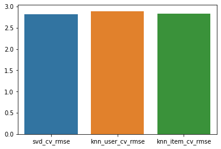

```python
# Comparison of RMSE scores(mean cv) from different collaorative algorithms
sns.barplot(y=[svd_cv['test_rmse'].mean(),knn_u_cv['test_rmse'].mean(), knn_i_cv['test_rmse'].mean()],
            x=['svd_cv_rmse','knn_user_cv_rmse', 'knn_item_cv_rmse'])
```

- Cross validation did not much affect the RMSE values. It was kind of almost similar to without CV.
- Only in case of SVD it worsened by 0.02 by doing a CV.

### 10. In what business scenario you should use popularity based Recommendation Systems?

Popularity based recommendation system relies on the popularity, trends and frequency counts of which items were most purchased.

It is used buy the travel companies selling holiday packages in a season, by Google News and other news websites to show Top Stories with images

Popularity based recommendation systems can be useful in multiple scenarios like:

- When there is no data about the user and items.
- When it is required to show most popular items in different categories along with personalized results like:
  - Most popular trend in western wear clothes or traditional wear clothes.
  - Most popular hindi songs or most popular english songs on a music website/app.
  - Most popular dishes of the restaurant (Recommended dishes in swiggy)
  - Most popular holiday packages for hiking trips, or bike trips or himalayan trips etc.

### 11. In what business scenario you should use CF based Recommendation Systems?

Collaborative Filtering is used to building intelligent recommender systems that can learn to give better recommendations as more information about users is collected.

It is a personalised recommender system , recommendations are made based on the past behaviour of the user.

Most websites like Amazon, YouTube, and Netflix use collaborative filtering as a part of their sophisticated recommendation system.

Collaborative filtering is useful in scenarios like:

- Giving personalised recommendation to the user, when user history or item data is available.
- Some examples can be:
  - Personalized movie recommendation of movie sites like Netflix, Amazon Prime, Youtube etc

### 12. What other possible methods can you think of which can further improve the recommendation for different users?

Content-based, Demographic, Utility based, Knowledge based, Hybrid recommendation system (like Content+Collaborative) methods can be used as per the user needs.